# Zonal Operations

Author

Marc Weber

Published

January 24, 2024

## What are zonal operations?

Zonal statistics have been around for a while - a zonal statistics operation is one that calculates statistics on cell values of a raster (a value raster) within the zones defined by another dataset.

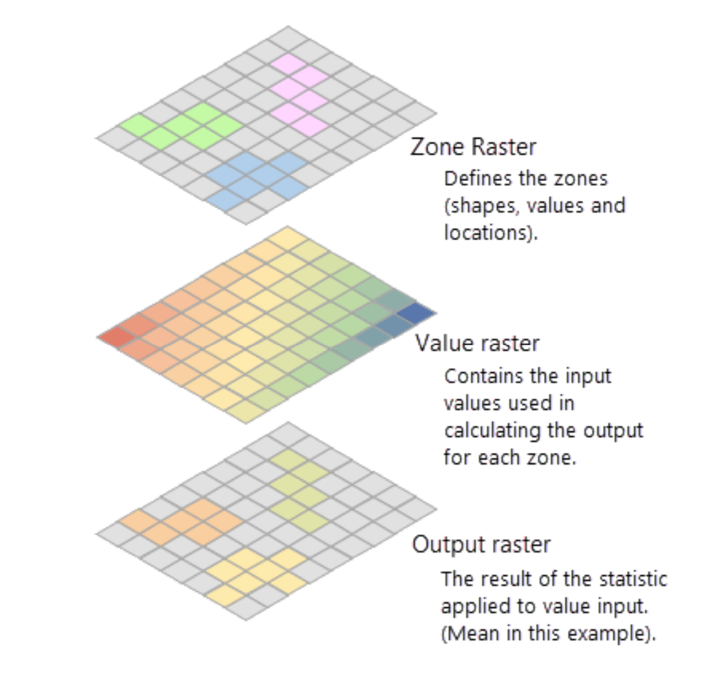

The [How zonal statistics tools work](https://pro.arcgis.com/en/pro-app/latest/tool-reference/spatial-analyst/how-zonal-statistics-works.htm#:~:text=A%20zonal%20statistics%20operation%20is,and%20Zonal%20Statistics%20as%20Table.) ArcPro documentation pages gives a great explanation.

*Categorical Raster summaries* are just a variety of zonal operations where we calculate cross-tabulated areas two datasets and ouput that as a table - in ArcPro this is called *Tabulate Area*

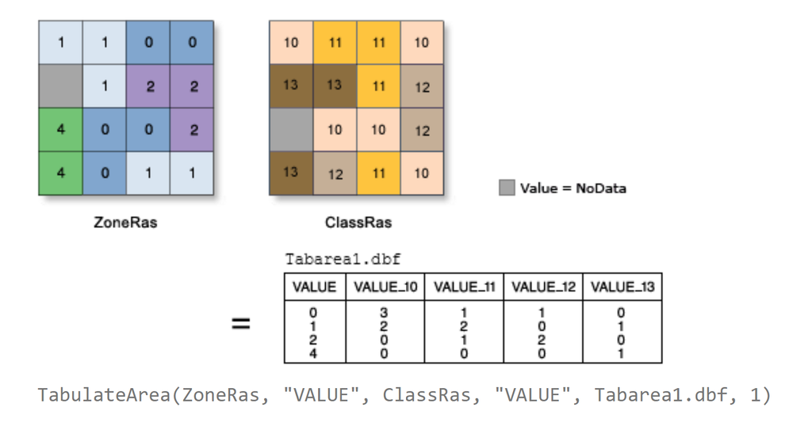

tabulate

## Zonal statistics ‘gotchas’

- Overlapping zones
- zonal operations using vector features as zones are running rasterizing vector features under the hood - need to be aware of the cell prioritization method:
  - cell center method used by default in zonal tools in ArcPro
  - Python [rasterstats](https://pythonhosted.org/rasterstats/manual.html) includes a nice discussion of rasterization strategy and parameterizes as `all_touched=False` (the cell center method) or `all-touched=True` (include all value grid cells that touch a polygon boundary)

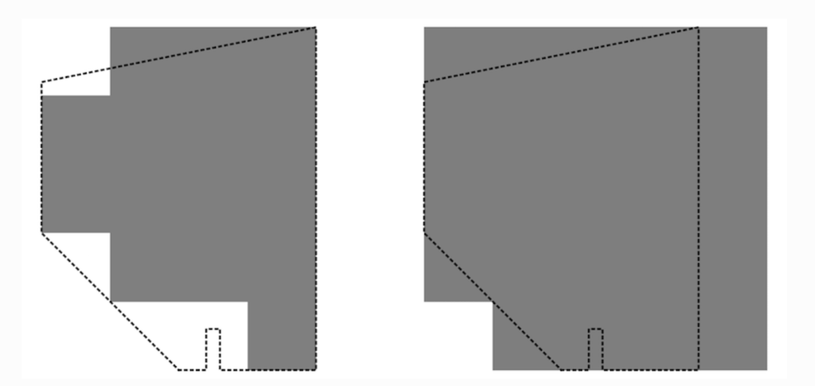

Rasterization

## Basic zonal stats with terra::zonal

More details in [EPA R spatial workshop from this past fall](https://usepa.github.io/spatialdata.epaR2023/geoprocessing.html#zonal-operations)

```r
AOI <- AOI::aoi_get(state = "oregon", county = "all")
mapview(AOI)
```

[interactive chart not shown]

```r
clay <- terra::rast('O:/PRIV/CPHEA/PESD/COR/CORFILES/Geospatial_Library_Projects/StreamCat/LandscapeRasters/QAComplete/clay.tif')
AOI <- st_transform(AOI,crs(clay))
clay_OR <- terra::crop(clay, vect(AOI))
system.time({
clay_zonal = terra::zonal(clay_OR, terra::vect(AOI), na.rm = TRUE, fun = "mean")
})
```

```
   user  system elapsed
 400.00   84.90  486.21
```

```r
head(clay_zonal)
```

```
      clay
1 2690.405
2 3393.002
3 2290.807
4 2259.614
5 2582.934
6 2571.893
```

## Basic zonal stats with `zonal::execute_zonal`

Same as above but using the `zonal` package

```r
system.time({
  clay_zonal = zonal::execute_zonal(data=clay_OR, geom=AOI, ID='fip_code',fun = "mean")
})
```

```
   user  system elapsed
  15.00    1.49   16.55
```

```r
head(clay_zonal[,c('fip_code','name','mean.clay')])
```

```
Simple feature collection with 6 features and 3 fields
Geometry type: MULTIPOLYGON
Dimension:     XY
Bounding box:  xmin: -2282144 ymin: 2521077 xmax: -1621680 ymax: 2906847
Projected CRS: NAD83 / Conus Albers
  fip_code      name mean.clay                       geometry
1    41001     Baker  2690.407 MULTIPOLYGON (((-1674311 25...
2    41003    Benton  3392.998 MULTIPOLYGON (((-2179123 26...
3    41005 Clackamas  2290.808 MULTIPOLYGON (((-1994417 27...
4    41007   Clatsop  2259.612 MULTIPOLYGON (((-2152642 28...
5    41009  Columbia  2582.931 MULTIPOLYGON (((-2055064 28...
6    41011      Coos  2571.892 MULTIPOLYGON (((-2229989 25...
```

## Categorical summary with `zonal::execute_zonal`

```r
nlcd <- terra::rast('L:/Priv/CORFiles/Geospatial_Library_Resource/PHYSICAL/LAND_USE_LAND_COVER/NLCD/nlcd2016/NLCD_2001_Land_Cover_L48_20190424.img')
AOI <- st_transform(AOI,crs(nlcd))
nlcd_OR <- terra::crop(nlcd, vect(AOI))

system.time({
  lc = zonal::execute_zonal(nlcd_OR, AOI, ID = "fip_code",
                      fun = "frac")
})
```

```
   user  system elapsed
  16.21    1.69   18.02
```

## Set up reticulate to find my conda environments

```r
library(reticulate)

use_condaenv("geo", conda="C:/Users/mweber/AppData/Local/miniforge3/envs/geo", required = TRUE)
```

## And more

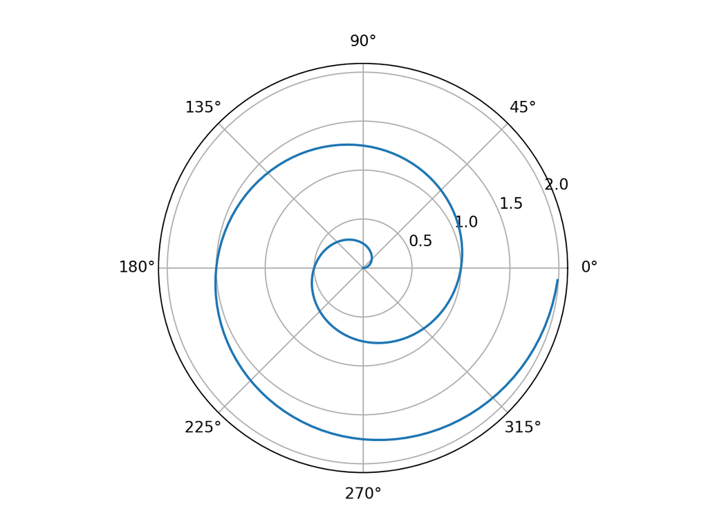

```python
import matplotlib.pyplot as plt
import numpy as np
r = np.arange(0, 2, 0.01)
theta = 2 * np.pi * r
fig, ax = plt.subplots(
  subplot_kw = {'projection': 'polar'}
)
ax.plot(theta, r)
ax.set_rticks([0.5, 1, 1.5, 2])
ax.grid(True)
plt.show()
```